# Practical Lab 3 - Vanilla CNN and Fine-Tune VGG16 - for Dogs and Cats Classification

In this lab, we will work through a common practice of Deep Learning Engineers - that is - take an existing model, that does something similar to what the engineer is interested doing, and fine-tune it for the specific task at-hand.

```python
import os, shutil, pathlib
import matplotlib.pyplot as plt
import seaborn as sns
import pandas as pd
import numpy as np
from PIL import Image
from tensorflow import keras
from tensorflow.keras import layers
from tensorflow.keras.utils import image_dataset_from_directory
from sklearn.metrics import confusion_matrix, classification_report, precision_recall_curve
```

1. Obtain the Data: Get the Dogs vs Cats dataset (see CSCN8010 class notebook)

```python
original_dir = pathlib.Path("./data/train/")
new_base_dir = pathlib.Path("./data/kaggle_dogs_vs_cats_small")

def make_subset(subset_name, start_index, end_index):
    for category in ("cat", "dog"):
        dir = new_base_dir / subset_name / category
        os.makedirs(dir)
        fnames = [f"{category}.{i}.jpg" for i in range(start_index, end_index)]
        for fname in fnames:
            shutil.copyfile(src=original_dir / fname,
                            dst=dir / fname)

make_subset("train", start_index=0, end_index=1000)
make_subset("validation", start_index=1000, end_index=1500)
make_subset("test", start_index=1500, end_index=2500)
```

2. EDA: Explore the data with relevant graphs, statistics and insights

```python
# Directories for train and test datasets
train_dir = './data/kaggle_dogs_vs_cats_small/train/'
validation_dir = './data/kaggle_dogs_vs_cats_small/validation/'
test_dir = './data/kaggle_dogs_vs_cats_small/test/'
```

```python
# 1. Basic statistics
num_train_cats = len(os.listdir(os.path.join(train_dir, 'cat')))
num_train_dogs = len(os.listdir(os.path.join(train_dir, 'dog')))
num_val_cats = len(os.listdir(os.path.join(validation_dir, 'cat')))
num_val_dogs = len(os.listdir(os.path.join(validation_dir, 'dog')))
num_test_cats = len(os.listdir(os.path.join(test_dir, 'cat')))
num_test_dogs = len(os.listdir(os.path.join(test_dir, 'dog')))
```

```python
statistics = {
    'Subset': ['Training', 'Validation', 'Test'],
    'Cats': [num_train_cats, num_val_cats, num_test_cats],
    'Dogs': [num_train_dogs, num_val_dogs, num_test_dogs]
}
```

```python
stats_df = pd.DataFrame(statistics)

print("Basic Statistics:")
print(stats_df)
```

```
Basic Statistics:
       Subset  Cats  Dogs
0    Training  1000  1000
1  Validation   500   500
2        Test  1000  1000
```

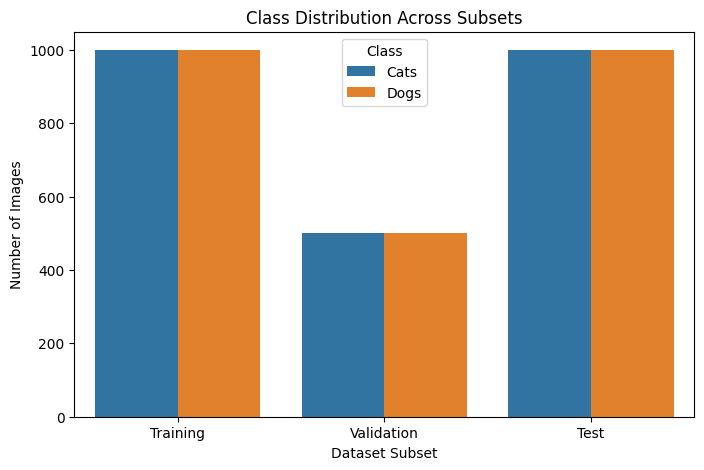

```python
plt.figure(figsize=(8, 5))
sns.barplot(x='Subset', y='value', hue='variable',
            data=pd.melt(stats_df, id_vars='Subset'))
plt.title('Class Distribution Across Subsets')
plt.ylabel('Number of Images')
plt.xlabel('Dataset Subset')
plt.legend(title='Class')
plt.show()
```

```python
def display_sample_images(dataset_dir, num_samples=5):
    fig, axes = plt.subplots(1, num_samples, figsize=(15, 5))
    category = ['cat', 'dog']

    for i, ax in enumerate(axes):
        label = category[i % 2]  # Alternate between cat and dog
        img_path = os.path.join(dataset_dir, label, f"{label}.{i}.jpg")
        img = Image.open(img_path)
        ax.imshow(img)
        ax.set_title(f"A sample {label}")
        ax.axis('off')
    plt.tight_layout()
    plt.show()
```

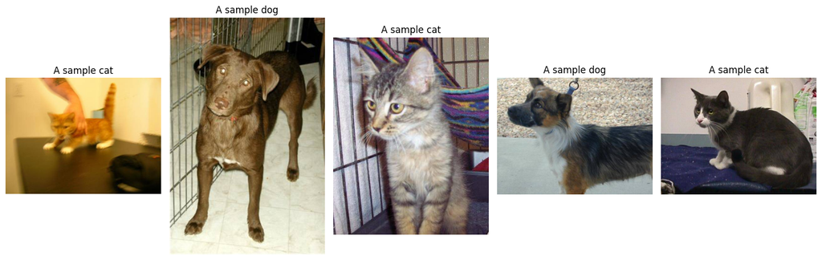

```python
display_sample_images(train_dir)
```

```python
# 4. Image Dimensions
train_cat_images = [Image.open(os.path.join(train_dir, 'cat', fname)) for fname in os.listdir(os.path.join(train_dir, 'cat'))]
train_dog_images = [Image.open(os.path.join(train_dir, 'dog', fname)) for fname in os.listdir(os.path.join(train_dir, 'dog'))]

cat_sizes = [img.size for img in train_cat_images]
dog_sizes = [img.size for img in train_dog_images]

cat_widths, cat_heights = zip(*cat_sizes)
dog_widths, dog_heights = zip(*dog_sizes)
```

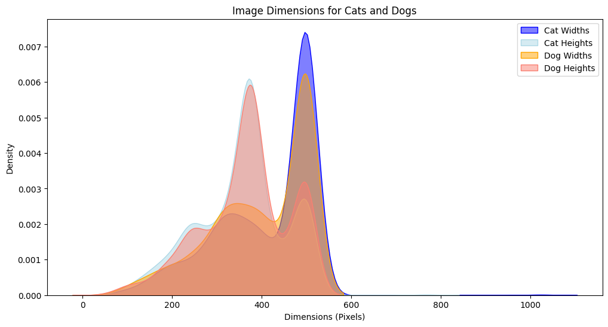

```python
plt.figure(figsize=(12, 6))
plt.title('Image Dimensions for Cats and Dogs')
sns.kdeplot(cat_widths, label='Cat Widths', color='blue', fill=True, alpha=0.5)
sns.kdeplot(cat_heights, label='Cat Heights', color='lightblue', fill=True, alpha=0.5)
sns.kdeplot(dog_widths, label='Dog Widths', color='orange', fill=True, alpha=0.5)
sns.kdeplot(dog_heights, label='Dog Heights', color='salmon', fill=True, alpha=0.5)
plt.xlabel('Dimensions (Pixels)')
plt.ylabel('Density')
plt.legend()
plt.show()
```

3. Train two networks (use callbacks to save the best model version):

   a. Define a Neural Network of your choice.

```python
data_folder = pathlib.Path('C:/Users/jaivb/OneDrive/Desktop/Foundational/FoundationalPub/Lab_3/data/kaggle_dogs_vs_cats_small')
```

```python
train_dataset = image_dataset_from_directory(
    data_folder / "train",
    image_size=(180, 180),
    batch_size=32)
validation_dataset = image_dataset_from_directory(
    data_folder / "validation",
    image_size=(180, 180),
    batch_size=32)
test_dataset = image_dataset_from_directory(
    data_folder / "test",
    image_size=(180, 180),
    batch_size=32)
```

```
Found 2000 files belonging to 2 classes.
Found 1000 files belonging to 2 classes.
Found 2000 files belonging to 2 classes.
```

Defining a Convolutional Neural Network(CNN)

```python
inputs = keras.Input(shape=(180, 180, 3))
x = layers.Rescaling(1./255)(inputs)
x = layers.Conv2D(filters=32, kernel_size=3, activation="relu")(x)
x = layers.MaxPooling2D(pool_size=2)(x)
x = layers.Conv2D(filters=64, kernel_size=3, activation="relu")(x)
x = layers.MaxPooling2D(pool_size=2)(x)
x = layers.Conv2D(filters=128, kernel_size=3, activation="relu")(x)
x = layers.MaxPooling2D(pool_size=2)(x)
x = layers.Conv2D(filters=256, kernel_size=3, activation="relu")(x)
x = layers.MaxPooling2D(pool_size=2)(x)
x = layers.Conv2D(filters=256, kernel_size=3, activation="relu")(x)
x = layers.Flatten()(x)
outputs = layers.Dense(1, activation="sigmoid")(x)
model = keras.Model(inputs=inputs, outputs=outputs)
```

```python
model.summary()
```

[output not shown]

```python
model.compile(loss="binary_crossentropy",
              optimizer="rmsprop",
              metrics=["accuracy"])
```

```python
callbacks = [
    keras.callbacks.ModelCheckpoint(
        filepath="./models/convnet_from_scratch.keras",
        save_best_only=True,
        monitor="val_loss")
]
history = model.fit(
    train_dataset,
    epochs=30,
    validation_data=validation_dataset,
    callbacks=callbacks)
```

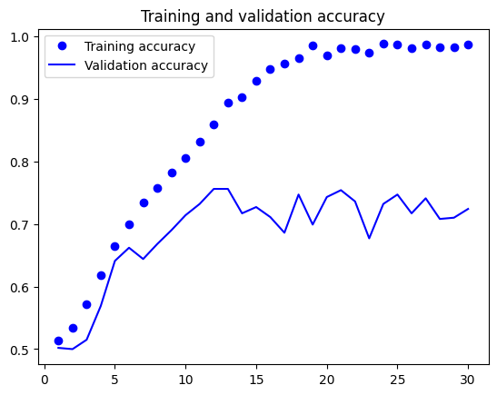

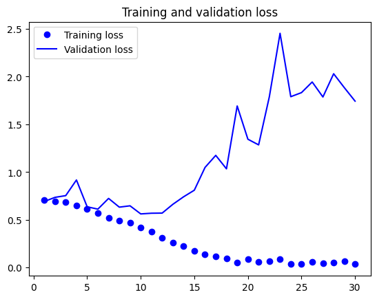

```python
accuracy = history.history["accuracy"]
val_accuracy = history.history["val_accuracy"]
loss = history.history["loss"]
val_loss = history.history["val_loss"]
epochs = range(1, len(accuracy) + 1)
plt.plot(epochs, accuracy, "bo", label="Training accuracy")
plt.plot(epochs, val_accuracy, "b", label="Validation accuracy")
plt.title("Training and validation accuracy")
plt.legend()
plt.figure()
plt.plot(epochs, loss, "bo", label="Training loss")
plt.plot(epochs, val_loss, "b", label="Validation loss")
plt.title("Training and validation loss")
plt.legend()
plt.show()
```

b. Fine-Tune VGG16 (pre-trained on imagenet). Make sure to use validation to test for over-fitting. Plot the appropriate graph.

```python
conv_base = keras.applications.vgg16.VGG16(
    weights="imagenet",
    include_top=False,
    input_shape=(180, 180, 3))
```

```python
conv_base.summary()
```

[output not shown]

```python
def get_features_and_labels(dataset):
    all_features = []
    all_labels = []
    for images, labels in dataset:
        preprocessed_images = keras.applications.vgg16.preprocess_input(images)
        features = conv_base.predict(preprocessed_images)
        all_features.append(features)
        all_labels.append(labels)
    return np.concatenate(all_features), np.concatenate(all_labels)

train_features, train_labels =  get_features_and_labels(train_dataset)
val_features, val_labels =  get_features_and_labels(validation_dataset)
test_features, test_labels =  get_features_and_labels(test_dataset)
```

```python
conv_base.compile(loss="binary_crossentropy",
              optimizer="rmsprop",
              metrics=["accuracy"])
```

```python
train_features.shape
```

```
(2000, 5, 5, 512)
```

```python
inputs = keras.Input(shape=(5, 5, 512))
x = layers.Flatten()(inputs)
x = layers.Dense(256)(x)
x = layers.Dropout(0.5)(x)
outputs = layers.Dense(1, activation="sigmoid")(x)
model_vgg16 = keras.Model(inputs, outputs)
```

```python
model_vgg16.summary()
```

[output not shown]

```python
model_vgg16.compile(loss="binary_crossentropy",
              optimizer="rmsprop",
              metrics=["accuracy"])

callbacks = [
    keras.callbacks.ModelCheckpoint(
      filepath="./models/feature_extraction.keras",
      save_best_only=True,
      monitor="val_loss")
]
history = model_vgg16.fit(
    train_features, train_labels,
    epochs=20,
    validation_data=(val_features, val_labels),
    callbacks=callbacks)
```

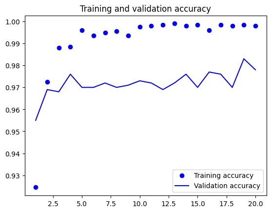

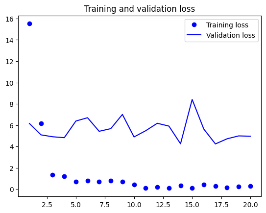

```python
acc = history.history["accuracy"]
val_acc = history.history["val_accuracy"]
loss = history.history["loss"]
val_loss = history.history["val_loss"]
epochs = range(1, len(acc) + 1)
plt.plot(epochs, acc, "bo", label="Training accuracy")
plt.plot(epochs, val_acc, "b", label="Validation accuracy")
plt.title("Training and validation accuracy")
plt.legend()
plt.figure()
plt.plot(epochs, loss, "bo", label="Training loss")
plt.plot(epochs, val_loss, "b", label="Validation loss")
plt.title("Training and validation loss")
plt.legend()
plt.show()
```

4. Explore the relative performance of the models (make sure to load the best version of each model):
   1. accuracy
   2. confusion metric
   3. precision, recall, F1-score,
   4. precision-recall curve.
   5. Explore specific examples in which the model failed to predict correctly.

```python
test_model_cnn = keras.models.load_model("./models/convnet_from_scratch.keras")
test_loss, test_acc = test_model_cnn.evaluate(test_dataset)
print(f"Test accuracy: {test_acc:.3f}")
```

```
Test accuracy: 0.714
```

A test accuracy of 71.4% (0.714). This suggests that the model is somewhat efficient, yet it still faces challenges with categorization.

```python
test_model_vgg16 = keras.models.load_model(
    "./models/feature_extraction.keras")
test_loss, test_acc = test_model_vgg16.evaluate(x=test_features, y=test_labels)
print(f"Test accuracy: {test_acc:.3f}")
```

```
Test accuracy: 0.974
```

Achieved a significantly higher test accuracy of 97.4% (0.974). This indicates that the VGG16 model performs exceptionally well on this dataset.

```python
vgg16_pred = (test_model_vgg16.predict(test_features) > 0.5).astype("int32")
cnn_pred = (test_model_cnn.predict(test_dataset) > 0.5).astype("int32")
```

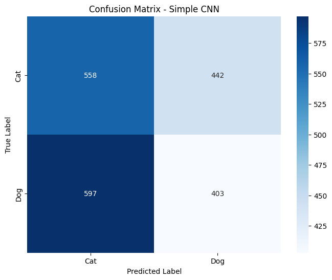

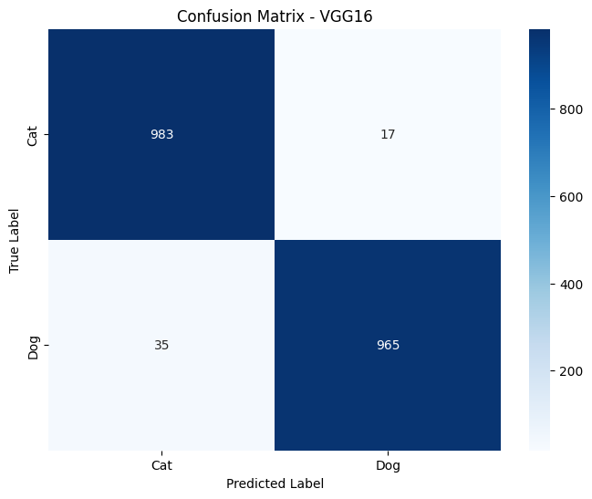

```python
cm_simple_cnn = confusion_matrix(test_labels, cnn_pred)
plt.figure(figsize=(8, 6))
sns.heatmap(cm_simple_cnn, annot=True, fmt='d', cmap='Blues', xticklabels=['Cat', 'Dog'], yticklabels=['Cat', 'Dog'])
plt.title('Confusion Matrix - Simple CNN')
plt.xlabel('Predicted Label')
plt.ylabel('True Label')
plt.show()

cm_vgg16 = confusion_matrix(test_labels, vgg16_pred)
plt.figure(figsize=(8, 6))
sns.heatmap(cm_vgg16, annot=True, fmt='d', cmap='Blues', xticklabels=['Cat', 'Dog'], yticklabels=['Cat', 'Dog'])
plt.title('Confusion Matrix - VGG16')
plt.xlabel('Predicted Label')
plt.ylabel('True Label')
plt.show()
```

- For CNN:
  - True Positives (Dogs) = 403, True Negatives (Cats) = 558
  - False Negatives (Dogs predicted as Cats) = 597, False Positives (Cats predicted as Dogs) = 442
  - The Simple CNN struggles to distinguish between classes, as evidenced by a substantial number of false positives and false negatives
- For VGG16:
  - True Positives (Dogs) = 965, True Negatives (Cats) = 983
  - False Negatives (Dogs predicted as Cats) = 35, False Positives (Cats predicted as Dogs) = 17
  - The VGG16 model shows a remarkable ability to classify both categories accurately, with very few misclassifications.This is likely due to the model's deeper architecture and the use of pre-trained weights.

```python
# Classification report for Simple CNN
print("Simple CNN Classification Report:\n", classification_report(test_labels, cnn_pred, target_names=['Cat', 'Dog']))

print("VGG16 Classification Report:\n", classification_report(test_labels, vgg16_pred, target_names=['Cat', 'Dog']))
```

```
Simple CNN Classification Report:
               precision    recall  f1-score   support

         Cat       0.48      0.56      0.52      1000
         Dog       0.48      0.40      0.44      1000

    accuracy                           0.48      2000
   macro avg       0.48      0.48      0.48      2000
weighted avg       0.48      0.48      0.48      2000

VGG16 Classification Report:
               precision    recall  f1-score   support

         Cat       0.97      0.98      0.97      1000
         Dog       0.98      0.96      0.97      1000

    accuracy                           0.97      2000
   macro avg       0.97      0.97      0.97      2000
weighted avg       0.97      0.97      0.97      2000
```

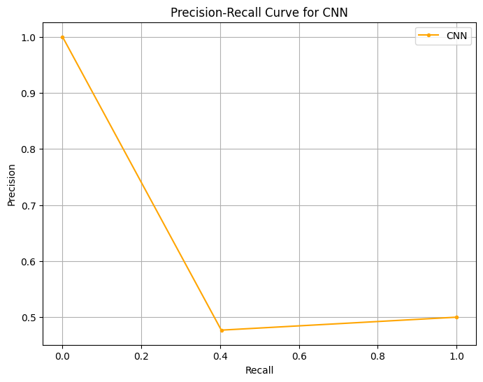

```python
precision_cnn, recall_cnn, _ = precision_recall_curve(test_labels, cnn_pred)
plt.figure(figsize=(8, 6))
plt.plot(recall_cnn, precision_cnn, marker='.', color='orange', label='CNN')
plt.title('Precision-Recall Curve for CNN')
plt.xlabel('Recall')
plt.ylabel('Precision')
plt.legend()
plt.grid()
plt.show()
```

The precision-recall curve indicates a significant drop in precision with rising recall, implying that while certain instances are correctly identified, the model is not consistently reliable.

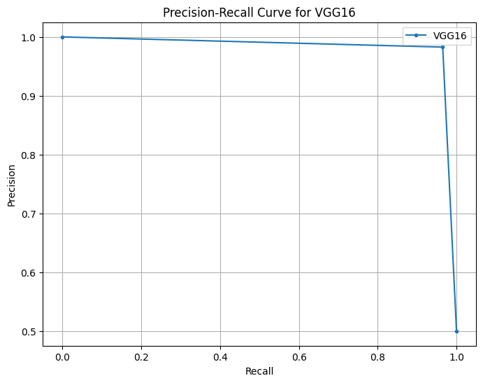

```python
precision_vgg, recall_vgg, _ = precision_recall_curve(test_labels, vgg16_pred)

plt.figure(figsize=(8, 6))
plt.plot(recall_vgg, precision_vgg, marker='.', label='VGG16')
plt.title('Precision-Recall Curve for VGG16')
plt.xlabel('Recall')
plt.ylabel('Precision')
plt.legend()
plt.grid()
plt.show()
```

[output not shown]

[figure not shown]

```python
def plot_misclassified_images(model, test_dataset, true_labels):
    # Getting the images and predictions from the model
    predictions = (model.predict(test_dataset) > 0.5).astype("int32")

    # Extract images and true labels from the dataset
    images = []
    for images_batch, labels_batch in test_dataset:
        images.append(images_batch.numpy())  # Convert to numpy array

    # Concatenate to get all images
    images = np.concatenate(images)

    # Identify misclassified indices
    misclassified_indices = np.where(true_labels != predictions.flatten())[0]

    # Set up for plotting
    plt.figure(figsize=(15, 15))
    for i, index in enumerate(misclassified_indices[:9]):  # Show first 9 misclassified
        plt.subplot(3, 3, i + 1)
        plt.imshow(images[index])
        plt.title(f"True: {'Dog' if true_labels[index] == 1 else 'Cat'}, Pred: {'Dog' if predictions[index] == 1 else 'Cat'}")
        plt.axis('off')
    plt.show()

plot_misclassified_images(test_model_cnn, test_dataset, test_labels)
```

5. Add your conclusions.

By looking at the results of classification of both models the performance metrics clearly indicate that the VGG16 model outperforms the Simple CNN dramatically in the classification task for the dataset concerning images of cats and dogs.

For misclassifications of VGG16 further fine tuning could give us more better results since it already looks in better shape.

While for CNN, we could explore the results with data augmentation or tuning.